# Data-cleaning & EDA

```python
from ipywidgets import interact, IntRangeSlider
from fuzzywuzzy import fuzz, process
import pandas as pd
import numpy as np
import seaborn as sns
import matplotlib.pyplot as plt
from bs4 import BeautifulSoup
from nltk.corpus import stopwords
from nltk.tokenize import wordpunct_tokenize
from pandas_profiling import ProfileReport
import re
from cleaning.cleaning import *
from cleaning.tag_scraping import scrap,make_links
#loadin the list of stop words
stop_words = set(stopwords.words('english'))
sns.set_style('whitegrid')
IT_stop = stop_words.copy()
IT_stop.discard('it') #excluding 'it'  from the stop words list
%matplotlib inline
```

```python
#reading data
data = pd.read_csv('data.csv', na_values='Select')
```

#### Parsing datetime

```python
datetime = pd.to_datetime(data.post_date)
temp = pd.DatetimeIndex(datetime)
data['date'] = temp.date
data['time'] = temp.time
data.set_index(pd.to_datetime(data.post_date),inplace=True)
data.drop('post_date',axis=1, inplace=True)
```

#### Fuzzy matching for the city_name

```python
matchs_list = list(data.city_name.value_counts().head(5).index) #most common values
data['city_name'] = data.city_name.apply(fuzzy_match, matchs_list=matchs_list)
```

#### Parsing the description, job_requirements coloums and removing the stop words

```python
data['description'] = data.description.apply(parse_html)
data['job_requirements'] = data.job_requirements.apply(parse_html)
```

```python
num_posts = data.groupby('date').count().id
```

#### Re-sampling weekly and plotting the number of job posting over time

```python
data['count'] = 1
```

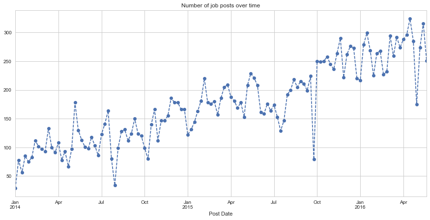

```python
ax = data['count'].resample("w").sum().plot(figsize=(15,7),kind='line',linestyle='--', marker='o',
                                           title='Number of job posts over time', )
ax.set_xlabel('Post Date');
```

#### Re-sampling weekly and plotting the number of views over time

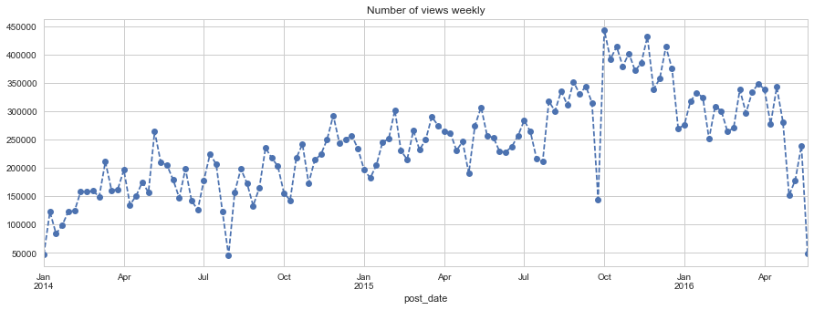

```python
ax = data.views.resample("w").sum().plot(figsize=(15,5),kind='line',linestyle='--', marker='o',
                                       title='Number of views weekly',);
```

#### It's not looking good, the trend seems to be going down so in the next plot will smooth it up a little by re-sampling monthly instead of weekly.

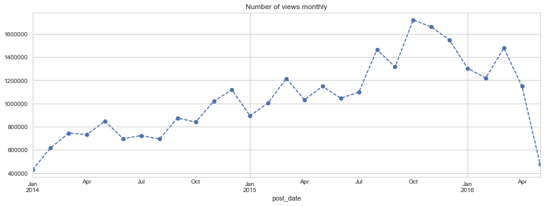

```python
ax = data.views.resample("m").sum().plot(figsize=(15,5),kind='line',linestyle='--', marker='o',
                                       title='Number of views monthly',);
```

#### Ploting the percent change for both [the number of viows over time, job posts over time]

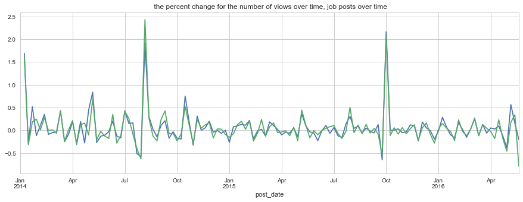

```python
plt.figure(figsize=(15,5))
data['count'].resample("w").sum().pct_change().plot(title=' the percent change for the number of viows over time, job posts over time')
data.views.resample("w").sum().pct_change().plot();
```

#### Not that informative so lets just see how the difference between the ‘number of job posts’ and ‘number views’ changes over time

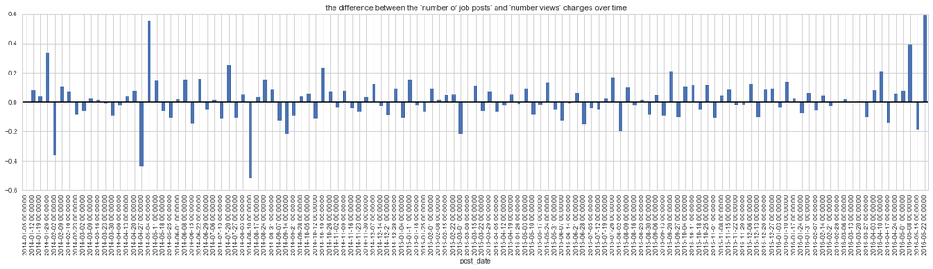

```python
plt.figure(figsize=(25,5))
pcc = data['count'].resample("w").sum().pct_change()
pcv = data.views.resample("w").sum().pct_change()
to_plot = (pcc - pcv).plot(kind='bar',title=' the difference between the ‘number of job posts’ and ‘number views’ changes over time');
plt.axhline(0, color='k');
plt.ylim(-.6,.6);
```

##### Explanation: the plot shows the weekly the times that the change of the number of posts was faster that the change in views and vice versa If the value is bigger than 0 it means the rate-of-change for the number of job posts is faster the rate-of-change of views. So, the one million EGP question or maybe the 100 dollars question by the time you’ll be reading this. It seems that the correlation between num_jobs and num_views is getting less stable, Is that bad? And the unsatisfying answer is not necessarily, and i do not know since i need to know the the relationship between the number of views and the number of jobs applications, and the relationship between number of applies and the probability of the job poster actually finding what they’re looking for. and I also need to study the effect of these changes in trends in the periods of stability and instability and the effect of that on hiring rate and if the difference is statistically meaningful of it can be due to randomness of even maybe social events

### Regression plot views on the x axis and number of posts on the y axis

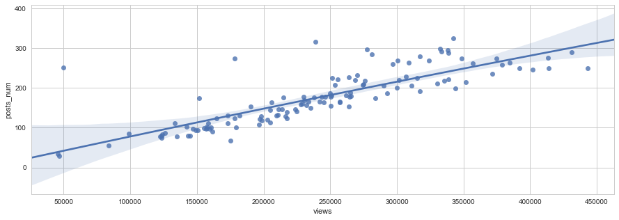

```python
sub2 = data[['date','views','count']]
reg_data = sub2.resample('w').sum()
reg_data.columns = ['views', 'posts_num']
plt.figure(figsize=(15,5))
ax= sns.regplot(x='views', y='posts_num', data=reg_data, order=2)
```

## Some random plots of the data to understand the data better

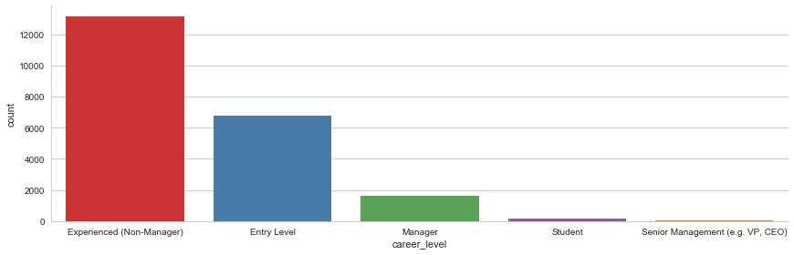

```python
ax = sns.factorplot(x='career_level', data=data, kind='count', aspect=3, palette="Set1",
               order=list(data.career_level.value_counts().index))
```

```python
data['mean_exper'] = data.experience_years.apply(mean_exper)
```

### The distribution Years of experience

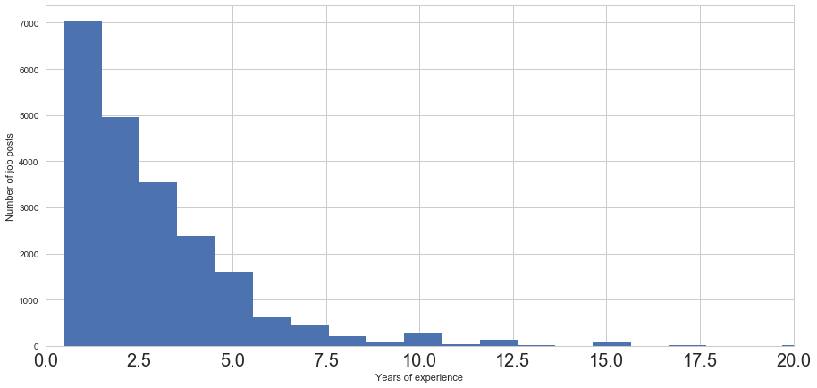

```python
ax = data.mean_exper.hist(bins=50, figsize=(15,7), xlabelsize=20, grid=True)
plt.xlim(0.0,20)
ax.set_xlabel('Years of experience')
ax.set_ylabel('Number of job posts');
```

```python
data['experience_years'] = data.experience_years.apply(clean_expr_years).fillna(np.nan)
```

```python
from cleaning.cleaning import job_plot
```

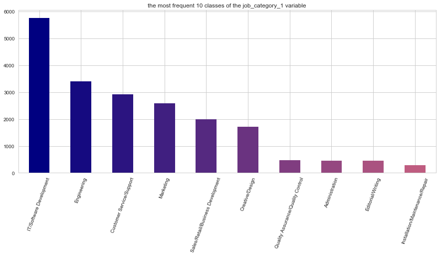

```python
ax = job_plot(data,'job_category_1',10)
ax.set_xticklabels(ax.xaxis.get_majorticklabels(), rotation=70);
```

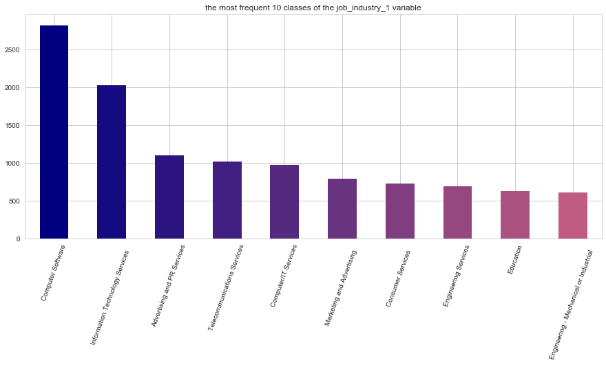

```python
ax = job_plot(data,'job_industry_1',10)
ax.set_xticklabels(ax.xaxis.get_majorticklabels(), rotation=70);
```

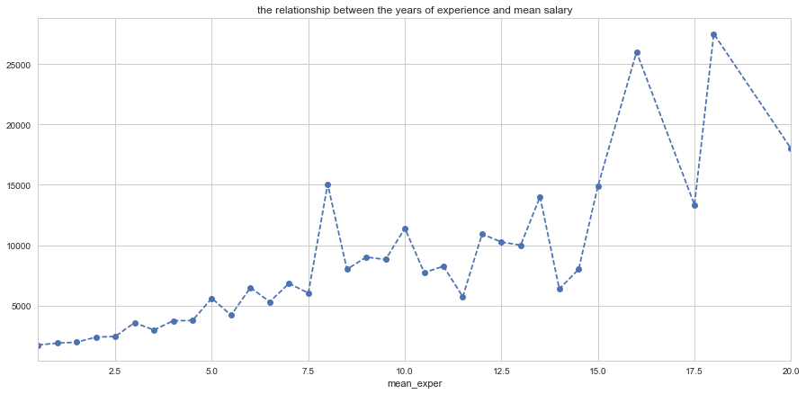

```python
data.groupby('mean_exper').salary_min.mean().ix[:20].plot(linestyle='--', marker='o', figsize=(15,7),
                                                         title='the relationship between the years of experience and mean salary');
```

### The spikes in the previous plot is due to in imbalance frequency of the classes

### While playing with the data i wondered does the number of filled data affect the number of views?

##### so let's see that.

```python
#sum the number of unfilled celles for every job post
alist = ['job_category_1', 'job_category_2', 'job_category_3', 'job_industry_3','job_industry_1', 'job_industry_2']
data['unfilled_info'] = data[alist].apply(pd.isnull).apply(sum,axis=1)
```

#### The number of views for every the number of the unfilled data

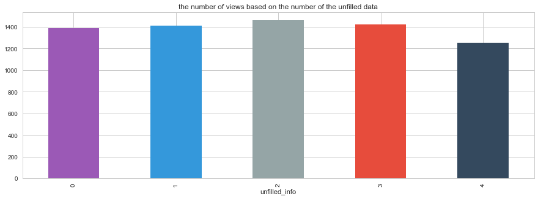

```python
f = ["#9b59b6", "#3498db", "#95a5a6", "#e74c3c", "#34495e", "#2ecc71"]
data.groupby('unfilled_info')['views'].mean()[:5].plot(kind='bar',
                                                       title='the number of views based on the number of the unfilled data',
                                                       color=f,figsize=(15,5));
```

#### It doesn't seem to have any significant effect however let's check the frequencies of every case of the number of unfilled cells.

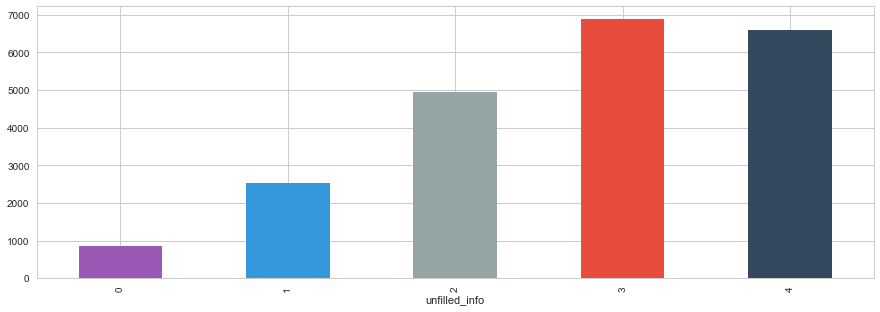

```python
ax = data.groupby('unfilled_info').agg('count')['count'].plot(kind='bar', figsize=(15,5), color=f)
ax.set_xlim(-.5,4.5);
```

well, the data is highly imbalanced but it's enough to be Representative. and the conclusion is that it's according to this data (and just this data) the number of filled cells from the columns ('job*category*(1,2,3)', 'job*industry*(1,2,3)') does not appear to be significant determinant of the number of views.

### note:

since I don't have access to the user data I don't have a way of knowing whether that conclusion is true for 'relevant views'* or not since probably the more date you fill the most likely it is that relevant views will increase and that might increase in relevant job application.

and that's true for all conclusions and that's what makes it nearly impossible to make almost any "Actionable insights" from this data.

all this data can provide is an interesting but incomplete view of the whole picture.

for analysis to be actionable it has to be backed by statistical evidence, that is taking a certain action is favorable over other action. and that's not easy that requires testing hypothesis and experiential design in this case for example (A/B testing - analyzing the trends before and after adding some feature to the website) and there are many steps to go from data to an actionable conclusion based on causal or highly correlated directorial relationships.

(*)(the views of users who are really interested in the job or the users who have skills relative to the job descriptions)